# ReferencesExample

Antonio Marquez Palacios

June 28, 2018

```r
library(tm)
```

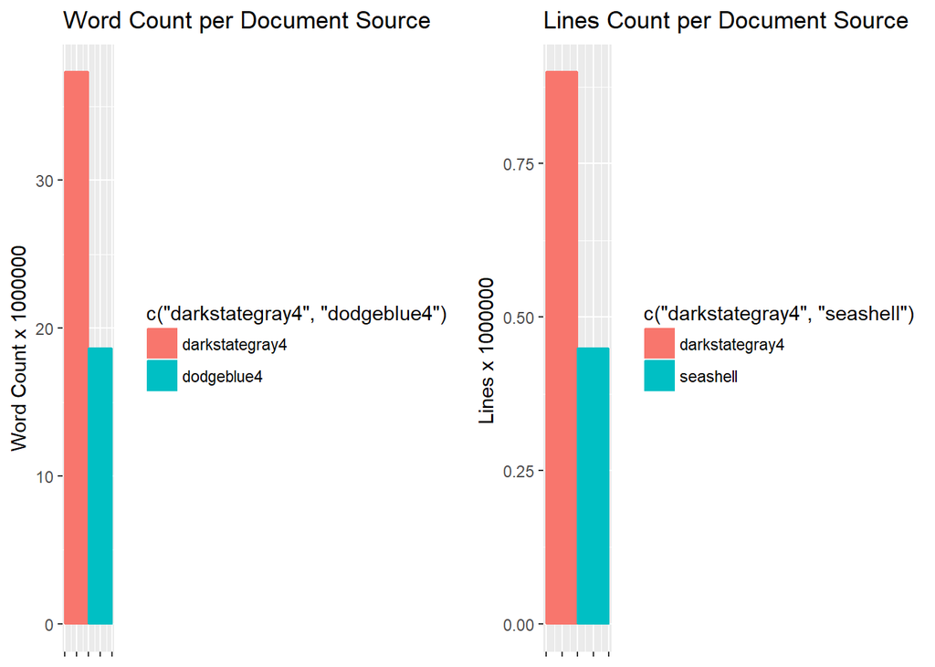

```r
library(stringi)
library(ggplot2)
library(SnowballC)
library(wordcloud)
library(RColorBrewer)
library(Rgraphviz)
library(gridExtra)
WORKING.BASE.DIR <- 'C:/datascience/specialization/swiftkey_project/final/en_US/'

# Previously set the WORKING.BASE.DIR = ../datascience/swiftkey/final/en_US
blogFile    <- file( paste(WORKING.BASE.DIR, "en_US.blogs.txt", sep = ""), open="rb")
blogText    <- readLines(blogFile, encoding = "latin1")
close(blogFile)
# Consider words are between spaces, so:
blogWordCount     <- sum(sapply(strsplit(blogText, " "), length))

blogLinesCount    <- NROW(blogText)
aMillion      <- 1000000
docsLines.df  <- data.frame(c('blogs', 'blogs/2'), c(blogLinesCount, blogLinesCount/2))

docsWord.df   <- data.frame(c('blogs', 'blogs/2'), c(blogWordCount, blogWordCount/2))

colnames(docsLines.df)<- c('source', 'count')
colnames(docsWord.df) <- c('source', 'count')

gWordCnt <- ggplot(docsWord.df, aes(ymin=0)) + geom_rect( aes( xmin=c(1,2), xmax=c(2,3), ymax=count/aMillion, colour=c('darkstategray4', 'dodgeblue4'), fill=c('darkstategray4', 'dodgeblue4'))) + theme(axis.text.x = element_blank()) + ylab("Word Count x 1000000") + ggtitle("Word Count per Document Source")

gLineCount <- ggplot(docsLines.df, aes(ymin=0)) + geom_rect( aes( xmin=c(1,2), xmax=c(2,3), ymax=count/aMillion, colour=c('darkstategray4','seashell'), fill=c('darkstategray4', 'seashell'))) + theme(axis.text.x = element_blank()) + ylab("Lines x 1000000 ") + ggtitle("Lines Count per Document Source")

grid.arrange(gWordCnt, gLineCount, nrow=1)
```

## Loading and cleaning the data

Data set consists of a zip file that can be downloaded from https://d396qusza40orc.cloudfront.net/dsscapstone/dataset/Coursera-SwiftKey.zip

It consists of plain text files with different sources: blog entries, twitter posts and news. Files for 4 different languages are included, as

- Deutsch
- English
- Finnish
- Russian

Across this report, only those files in English will be processed, this to ease and shorten the exercise.

## References

[Text Mining in R: A Tutorial](https://www.springboard.com/blog/text-mining-in-r/)  
[TM Package documentation - CRAN](https://cran.r-project.org/web/packages/tm/vignettes/tm.pdf) [Statistical Journal - Text Mining Infrastructure in](https://www.jstatsoft.org/article/view/v025i05)  
[A gentle introduction to text mining using R](https://eight2late.wordpress.com/2015/05/27/a-gentle-introduction-to-text-mining-using-r/)  
[n-gram](https://en.wikipedia.org/wiki/N-gram)  
[Text mining and word cloud fundamentals in R : 5 simple steps you should know](http://www.sthda.com/english/wiki/text-mining-and-word-cloud-fundamentals-in-r-5-simple-steps-you-should-know)  
[tm Package FAQ](http://tm.r-forge.r-project.org/faq.html)  
[Bioconductor Rgraphviz](https://www.bioconductor.org/packages/release/bioc/html/Rgraphviz.html)